# Lesson 5

### Multivariate Data

Notes: analyzing multi variable ***

### Moira Perceived Audience Size Colored by Age

Notes: she added color to the scatter plot but that didtn change anything. ***

### Third Qualitative Variable

```r
fb=read.delim('pseudo_facebook.tsv')
suppressMessages(library(dplyr))
```

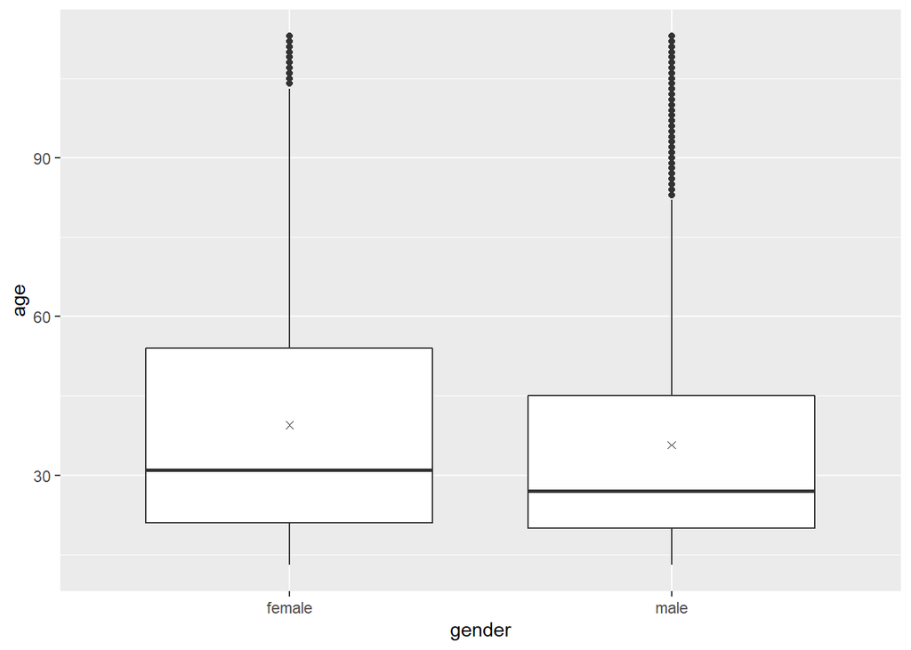

```r
#when using geom_histogram, You need to include stat=identity, which is basically telling ggplot2 you will provide the y-values for the barplot, rather than counting the aggregate number of rows for each x value, which is the default stat=count

library(ggplot2)

ggplot(aes(x = gender, y = age),data = subset(fb, !is.na(gender)))+
  geom_boxplot()+ stat_summary(fun=mean, geom='point', shape=4)
```

averages marked by an (x) since i used shape=4(which indeicate the angle of maks), we can see that the age of men is lower than relatively to women. so we might say actually think that a sample male to female comparison doesnt capture the substantial differences in friend_count.

lets look at median friend count by age and gender instead.

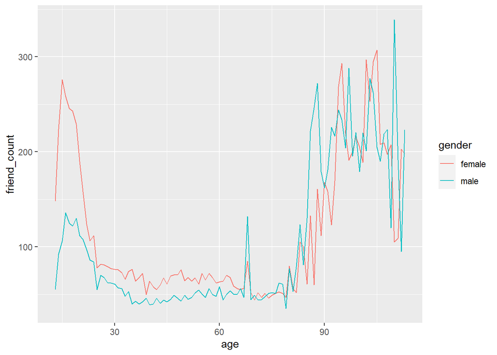

```r
ggplot(aes(x = age, y = friend_count),data = subset(fb, !is.na(gender)))+
  geom_line(aes(color=gender), stat='summary', fun=median)
```

we can see that nearly everywhere the median freind count for women is larger than its for men. Now, there are some exceptions, and this includes these noisy estimates for our very old users. Now i am using “old users” because we are not very confident about thes reported ages. and notice that the users reporting to be 70 have more or less the same friend count, regardles of reported gender .

we are going to reproduce the same plot but first lets see if we can create the summary data to create it ### Insruction Write code to create a new data frame, called ‘pf.fc_by_age_gender’, that contains information on each age AND gender group.

The data frame should contain the following variables: mean_friend_count, median_friend_count, n (the number of users in each age and gender grouping)

Here is an example of the structure of your data frame. Your data values will be different. Note that if you are grouping by more than one variable, you will probably need to call the ungroup() function.

age gender mean_friend_count median_friend_count n 1 13 female 247.2953 150 207 2 13 male 184.2342 61 265 3 14 female 329.1938 245 834 4 14 male 157.1204 88 1201

ENTER YOUR CODE BELOW THIS LINE. ==============================================================

age_group <- group_by(pf, age, gender) pf.fc_by_age_gender <- summarise(age_group, mean_friend_count = mean(friend_count), median_friend_count = median(friend_count), n = n())

```r
#However I will use that pipeline method: chian function together

fb_fc_by_age_gender=fb%>%
  filter(!is.na(gender))%>%
  group_by(age, gender) %>%
  summarise(mean_friend_count=mean(friend_count),
            median_friend_count=median(friend_count),
            n=n()) %>%
  arrange(age)
fb_fc_by_age_gender
```

```
## # A tibble: 202 x 5
## # Groups:   age [101]
##      age gender mean_friend_count median_friend_count     n
##    <int> <chr>              <dbl>               <dbl> <int>
##  1    13 female              259.               148     193
##  2    13 male                102.                55     291
##  3    14 female              362.               224     847
##  4    14 male                164.                92.5  1078
##  5    15 female              539.               276    1139
##  6    15 male                201.               106.   1478
##  7    16 female              520.               258.   1238
##  8    16 male                240.               136    1848
##  9    17 female              539.               246.   1236
## 10    17 male                236.               125    2045
## # ... with 192 more rows
```

### Plotting Conditional Summaries

Notes: Create a line graph showing the median friend count over the ages for each gender. Be sure to usethe data frame you just created, fb_fc_by_age_gender.

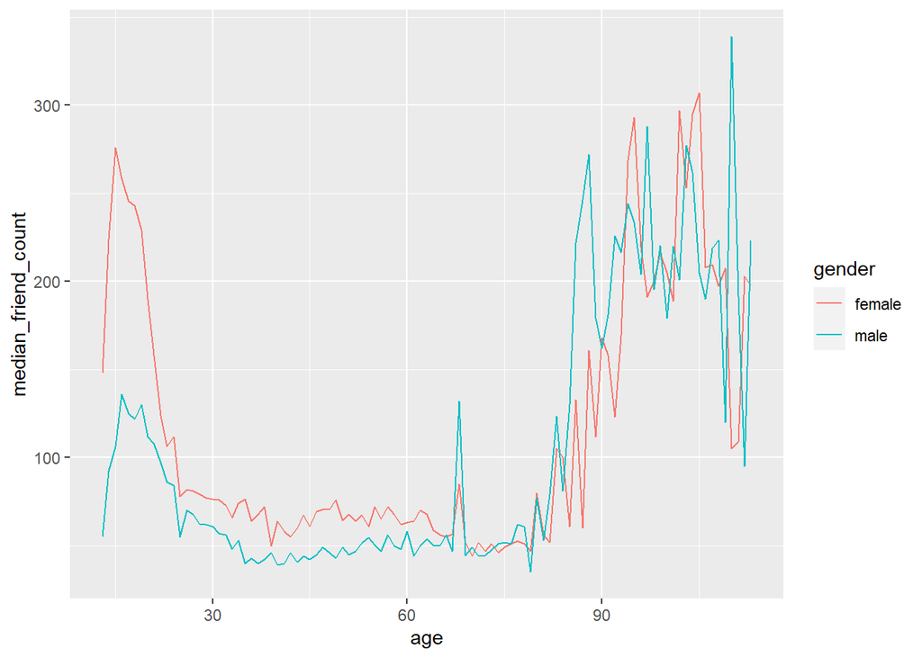

```r
ggplot(aes(age, median_friend_count), data=fb_fc_by_age_gender)+
  geom_line(aes(color=gender))
```

```r
#You could also use color = gender inside the aes() wrapper of ggplot().
```

so we produced the same exact plot as the first one, with (stat=‘summar’)

### Thinking in Ratios

Notes: the above plot would be useful if we want to inspect or carry out further operations to help us how the difference male and female frind_count users vary with the age. looking at the plot, it seems like the gender differnece is largest for our young users, it would be to put this in relative terms though. so, lets answer a different question how many times more friends does the average female users have than the male users? maybe female have twice as many friends as male users or maybe its ten times as many friends?

### Wide and Long Format

Notes: to answer the above question, we need to rearrange the data from long(many rows which are repeated for female and male) format to wide format

### Reshaping Data

Notes:I think you will find the tidyr package easier to use than the reshape2 package. Both packages can get the job done.

```r
#install.packages('reshape2')
library(reshape2)
#add the same dataframe we created and convert it to a wide df:
#dcast is udef for dataframe, for array or matrix we use: acast

fb_fc_by_age_gender_wide=dcast( fb_fc_by_age_gender,
        age~gender, #this means keep age as its and make new column for gender values.
        value.var = 'median_friend_count')

head(fb_fc_by_age_gender_wide)
```

```
##   age female  male
## 1  13  148.0  55.0
## 2  14  224.0  92.5
## 3  15  276.0 106.5
## 4  16  258.5 136.0
## 5  17  245.5 125.0
## 6  18  243.0 122.0
```

### Alternative method of long to wider:

```r
library(tidyr)
fb_fc_by_age_gender_wide <-
  subset(fb_fc_by_age_gender[c('age', 'gender', 'median_friend_count')],
         !is.na(gender)) %>%
  spread(gender, median_friend_count) %>%
  mutate(ratio = male / female)

head(fb_fc_by_age_gender_wide)
```

```
## # A tibble: 6 x 4
## # Groups:   age [6]
##     age female  male ratio
##   <int>  <dbl> <dbl> <dbl>
## 1    13   148   55   0.372
## 2    14   224   92.5 0.413
## 3    15   276  106.  0.386
## 4    16   258. 136   0.526
## 5    17   246. 125   0.509
## 6    18   243  122   0.502
```

#learn how to convert wide to long:

```r
arrange(melt(fb_fc_by_age_gender_wide, id.vars = 'age', measure.vars = c('male','female')),age)
```

```
##     age variable value
## 1    13     male  55.0
## 2    13   female 148.0
## 3    14     male  92.5
## 4    14   female 224.0
## 5    15     male 106.5
## 6    15   female 276.0
## 7    16     male 136.0
## 8    16   female 258.5
## 9    17     male 125.0
## 10   17   female 245.5
## 11   18     male 122.0
## 12   18   female 243.0
## 13   19     male 130.0
## 14   19   female 229.0
```

[output cut: 188 more lines]

### Ratio Plot

Notes:

Plot the ratio of the female to male median_friend_counts using the data frame fb_fc_by_age_gender_wide. Think about what geom you should use. Add a horizontal line to the plot with a y intercept of 1, which will be the base line. Look up the documentation for geom_hline to do that. Use the parameter linetype in geom_hline to make the line dashed.

The linetype parameter can take the values 0-6:

0 = blank, 1 = solid, 2 = dashed 3 = dotted, 4 = dotdash, 5 = longdash 6 = twodash

# ENTER YOUR CODE BELOW THIS LINE

geom_hline:There are two ways to use it. You can either specify the intercept of the line in the call to the geom, in which case the line will be in the same position in every panel. Alternatively, you can supply a different intercept for each panel using a data.frame. See the examples for the differences

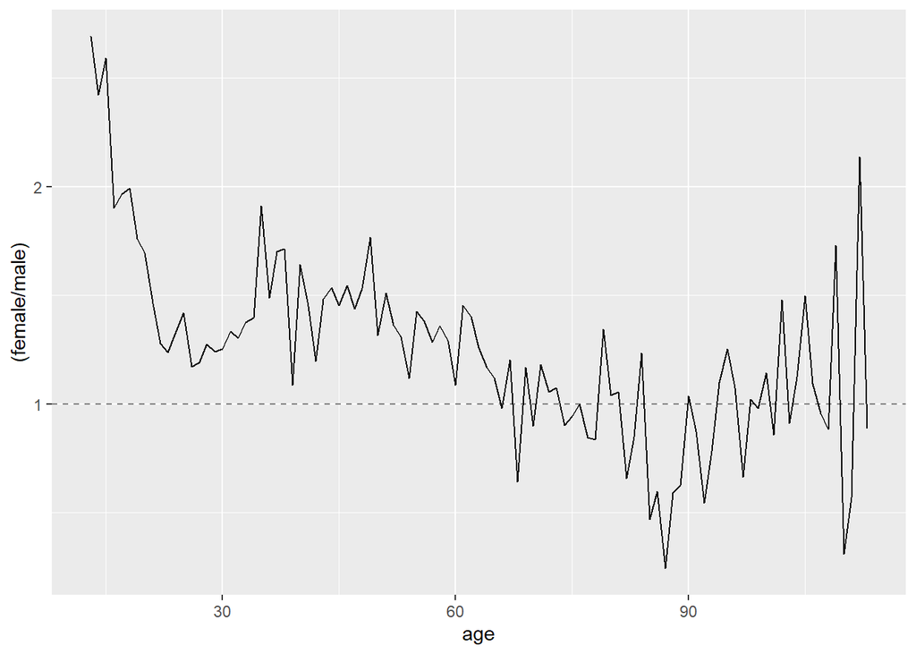

```r
ggplot(aes(x = age, y = (female/male)), data = fb_fc_by_age_gender_wide)+
  geom_line() +
  geom_hline(linetype = 2,alpha=0.5, yintercept = 1)
```

we can easily see that for young users th median female users have over two and a half time as many friends as the median male users. clearly it was helpful to condition on age and understanding the relationship of gender with friend_count. this helped assures us that the this patern is robust for users of many differnet ages. and it also highlighted where this differences is most striking. Now there are many processes that can produce this difference, including the baised distribution from which psuedo facebook data was generated. one idea which shows the complexity of interpretation here is that peole from particular countries who more recently joined facebook are more likely to be male with lower friends_counts

### Third Quantitative Variable

Notes: what if we look at age and friend_count over numerical varibale instead of categorical variable. we might notice that users likely to accumalate friends over tenure(how many days registerin in facebook) that facebook is imortant for predicting friends_count. tenure is associated with age.

Create a variable called year_joined in the pf data frame using the variable tenure and 2014 as the reference year. The variable year joined should contain the year that a user joined facebook.

```r
fb$year_joined= floor(2014 - (fb$tenure/365))

View(fb)
```

### Cut a Variable

Notes: What situation is cut useful in?

In many data analysis settings, it might be useful to break up a continuous variable such as age into a categorical variable. Or, you might want to classify a categorical variable like year into a larger bin, such as 1990-2000. There are many reasons not to do this when performing regression analysis, but for simple displays of demographic data in tables, it could make sense. The cut function in R makes this task simple! The cut function is useful for turning continuous variables into factors.

```r
print(summary(fb$year_joined))
```

```
##    Min. 1st Qu.  Median    Mean 3rd Qu.    Max.    NA's
##    2005    2012    2012    2012    2013    2014       2
```

```r
print(table(fb$year_joined))
```

```
##
##  2005  2006  2007  2008  2009  2010  2011  2012  2013  2014
##     9    15   581  1507  4557  5448  9860 33366 43588    70
```

Create a new variable in the data frame called year_joined.bucket by using the cut function on the variable year_joined. You need to create the following buckets for the new variable, year_joined.bucket

```
  (2004, 2009]
  (2009, 2011]
  (2011, 2012]
  (2012, 2014]
```

Note that a parenthesis means exclude the year and a bracket means include the year.

```r
fb$year_joined.bucket <- cut(fb$year_joined, breaks = c(2004, 2009, 2011, 2012, 2014))
```

### Plotting it All Together

Notes:plot friends_count over ages with each year_joined as we early did with gender. we will use the same plot structure.

```r
table(fb$year_joined.bucket, useNA = 'ifany')
```

```
##
## (2004,2009] (2009,2011] (2011,2012] (2012,2014]        <NA>
##        6669       15308       33366       43658           2
```

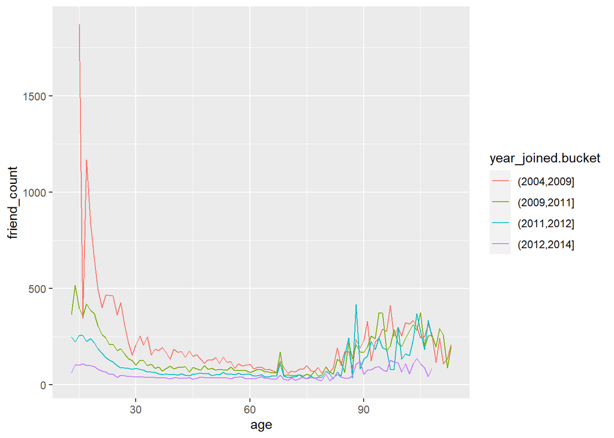

```r
ggplot(aes(x=age, y=friend_count), data=subset(fb, !is.na(year_joined.bucket)))+
  geom_line(aes(color=year_joined.bucket), stat='summary', fun=median)
```

### Plot the Grand Mean

Notes:looking at the plot we can see that our suspicion is confirm, users with longer tenure is having higher friened_counts with exception of older users see about 80 and up.to put these cohort specific medians in perspective, we can change them to cohort specific means and then plot the grand down as well. the grand mean is the line we saw in lesson 4 when nwe plotted average friend_count across ages

#Instruction (1) Add another geom_line to code below to plot the grand mean of the friend count vs age. (2) Exclude any users whose year_joined.bucket is NA. (3) Use a different line type for the grand mean. As a reminder, the parameter linetype can take the values 0-6:

0 = blank, 1 = solid, 2 = dashed 3 = dotted, 4 = dotdash, 5 = longdash 6 = twodash

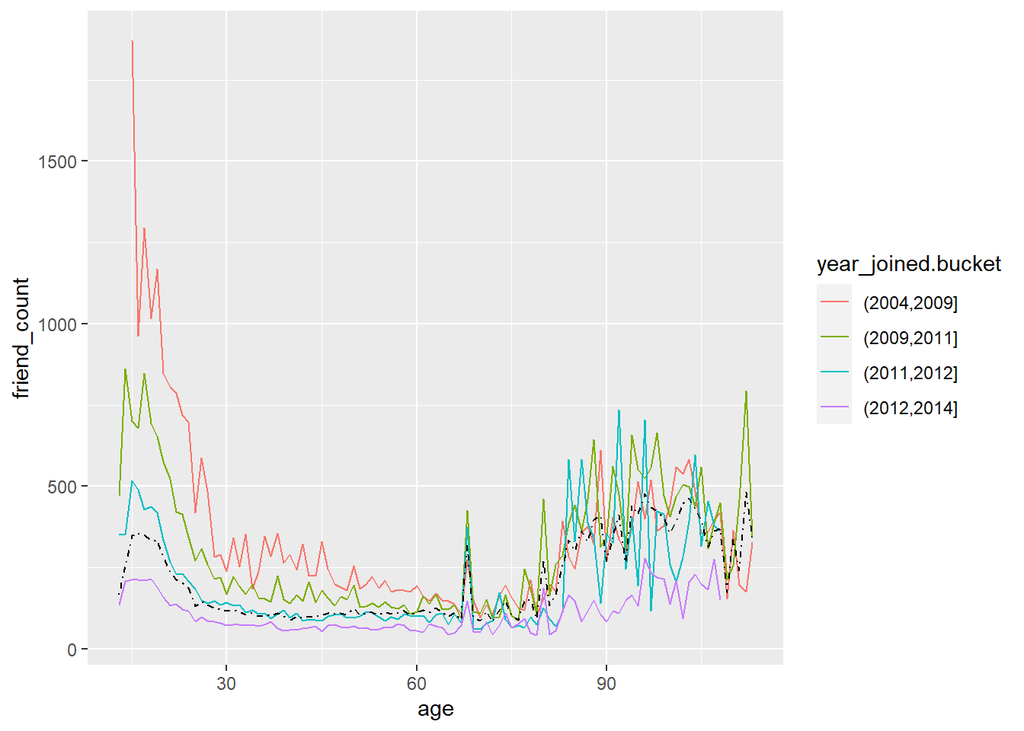

```r
ggplot(aes(x=age, y= friend_count), data=subset(fb, !is.na(year_joined.bucket)))+
  geom_line(aes(color=year_joined.bucket), stat= 'summary', fun=mean)+
  geom_line(stat = 'summary', fun = mean, linetype = 4)
```

plotting a grand mean is a good reminder that much of the data in the sample is about members of recent cohort (2011-2012). this is the type of high level observation we make in data.

### Friending Rate

Notes:since the general pattern continues to hold after conditioning on each of the buckets of the year_joined we might increase our confidence that this observation isnt just an artifact of the time users have had to accumulate friends. lets look at this. lets look at this relatonship in another way. we could also look at tenure and freind_count as a rate instead. for example: how many friends does a user have for each day since starting the service.

```r
#users who have used fb at least one day

with (subset(fb, tenure>=1), summary(friend_count/tenure))
```

```
##     Min.  1st Qu.   Median     Mean  3rd Qu.     Max.
##   0.0000   0.0775   0.2205   0.6096   0.5658 417.0000
```

median=0.2205 max=417

looking at our 3rd quantile, the max is definitly outlier considering our data.

### Friendships Initiated

Notes:if friend request across age groups are same or different. do new users have go on friend spree? or do users wiht more tenure initiate friendship

#instruction Create a line graph of mean of friendships_initiated per day (of tenure) vs. tenure colored by year_joined.bucket. You need to make use of the variables tenure, friendships_initiated, and year_joined.bucket. You also need to subset the data to only consider user with at least one day of tenure.

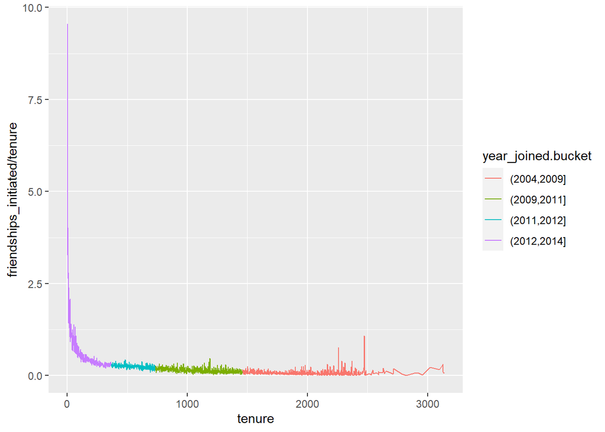

```r
ggplot(aes(x = tenure, y = friendships_initiated/tenure),
       data = subset(fb, fb$tenure >= 1))+
geom_line(aes(color = year_joined.bucket), stat= 'summary', fun = mean)
```

it appears that people with more tenure typically initiate less friendship.

### Bias-Variance Tradeoff Revisited

Notes:there is a lot of noise in our graph, since we are plotting the mean of y for every possible tenure x value. recall from lesson 4 that we can adjust this noise by bending our x-axis differently. let me show you one of those changes in our bin width.instead of using tenure here i am gonna replace this with differnt version or formula so that i can bend some of tenures together, lets see the difference when we plot this.

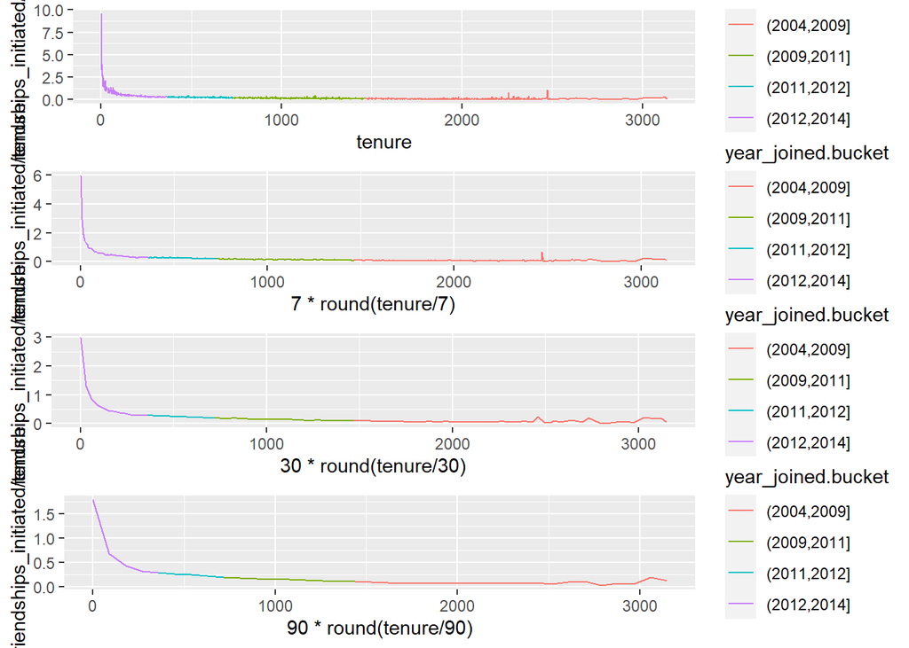

```r
p1= ggplot(aes(x = tenure, y = friendships_initiated / tenure),
       data = subset(fb, tenure >= 1)) +
  geom_line(aes(color = year_joined.bucket),
            stat = 'summary',
            fun = mean)

p2= ggplot(aes(x = 7 * round(tenure / 7), y = friendships_initiated / tenure),
       data = subset(fb, tenure > 0)) +
  geom_line(aes(color = year_joined.bucket),
            stat = "summary",
            fun = mean)

p3= ggplot(aes(x = 30 * round(tenure / 30), y = friendships_initiated / tenure),
       data = subset(fb, tenure > 0)) +
  geom_line(aes(color = year_joined.bucket),
            stat = "summary",
            fun = mean)

p4= ggplot(aes(x = 90 * round(tenure / 90), y = friendships_initiated / tenure),
       data = subset(fb, tenure > 0)) +
  geom_line(aes(color = year_joined.bucket),
            stat = "summary",
            fun= mean)

library(gridExtra)
grid.arrange(p1,p2,p3,p4, ncol=1)
```

notice how slightly less noise we get in plot whenever i multiply it with bigger number. we see with the number 90 very high bias but much less variance. Notice as the bin size increases we see less noise on the plot. our estimates are adjusted since we have more data points for our new values of tenure. in lesson four we introduced as a smoother as one tool for an analyst to use in these type of situation. so instead of using geom_line() here, I would like to use geom_smooth to add a smoother to this.

NOTE: The code changing the binning is substituting x = tenure in the plotting expressions with x = 7 * round(tenure / 7), etc., binning values by the denominator in the round function and then transforming back to the natural scale with the constant in front.

Learn about [Bias_variance Trade-off](http://scott.fortmann-roe.com/docs/BiasVariance.html)

#instruction Instead of geom_line(), use geom_smooth() to add a smoother to the plot. You can use the defaults for geom_smooth() but do color the line by year_joined.bucket Remember: we are using just geom_smooth, R will just use a perfect statistical method based on our data.

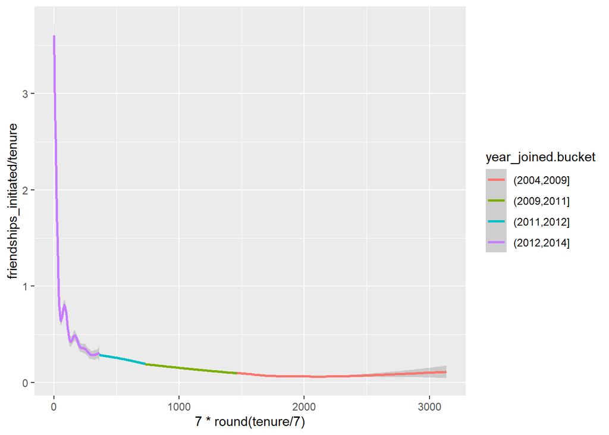

```r
ggplot(aes(x = 7 * round(tenure / 7), y = friendships_initiated / tenure),
       data = subset(fb, tenure > 0)) +
  geom_smooth(aes(color = year_joined.bucket))
```

### Sean’s NFL Fan Sentiment Study

Notes:

### Introducing the Yogurt Data Set

Notes: dataframe of the household that buy yogurt over time:

```r
yogurt=read.csv("yogurt.csv")

str(yogurt)
```

```
## 'data.frame':    2380 obs. of  9 variables:
##  $ obs        : int  1 2 3 4 5 6 7 8 9 10 ...
##  $ id         : int  2100081 2100081 2100081 2100081 2100081 2100081 2100081 2100081 2100081 2100081 ...
##  $ time       : int  9678 9697 9825 9999 10015 10029 10036 10042 10083 10091 ...
##  $ strawberry : int  0 0 0 0 1 1 0 0 0 0 ...
##  $ blueberry  : int  0 0 0 0 0 0 0 0 0 0 ...
##  $ pina.colada: int  0 0 0 0 1 2 0 0 0 0 ...
##  $ plain      : int  0 0 0 0 0 0 0 0 0 0 ...
##  $ mixed.berry: int  1 1 1 1 1 1 1 1 1 1 ...
##  $ price      : num  59 59 65 65 49 ...
```

change the id from an integer to factor:

```r
yogurt$id = factor(yogurt$id)

str(yogurt)
```

```
## 'data.frame':    2380 obs. of  9 variables:
##  $ obs        : int  1 2 3 4 5 6 7 8 9 10 ...
##  $ id         : Factor w/ 332 levels "2100081","2100370",..: 1 1 1 1 1 1 1 1 1 1 ...
##  $ time       : int  9678 9697 9825 9999 10015 10029 10036 10042 10083 10091 ...
##  $ strawberry : int  0 0 0 0 1 1 0 0 0 0 ...
##  $ blueberry  : int  0 0 0 0 0 0 0 0 0 0 ...
##  $ pina.colada: int  0 0 0 0 1 2 0 0 0 0 ...
##  $ plain      : int  0 0 0 0 0 0 0 0 0 0 ...
##  $ mixed.berry: int  1 1 1 1 1 1 1 1 1 1 ...
##  $ price      : num  59 59 65 65 49 ...
```

### Histograms Revisited

Notes:

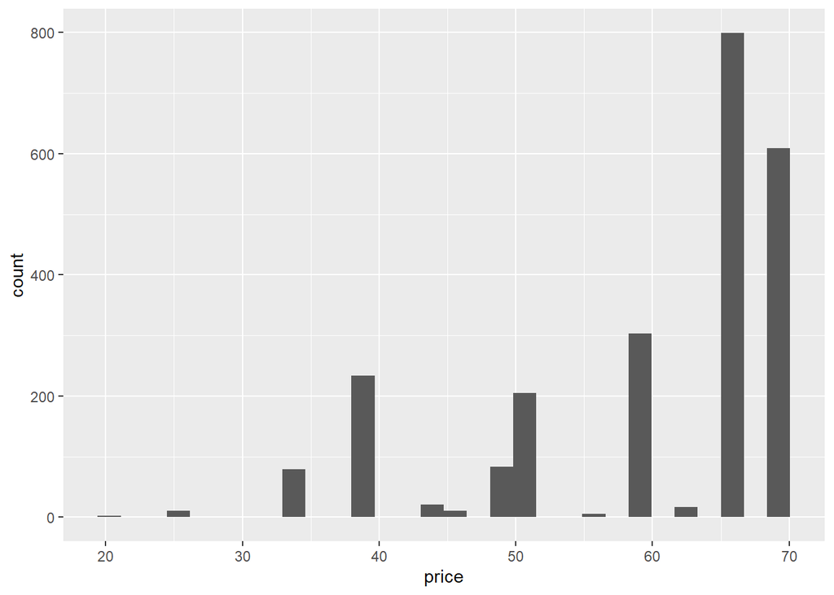

```r
ggplot(aes(price), data=yogurt)+geom_histogram()
```

we immediately notice some important discreteness to this distribution, there are appear to be prices which there are many observations, but then no observation in adjacent prices. this makes sense if prices are set in a way that applies to many of the consumers. there are some purchases that involve much lower prices and if we are interested in price sensitivity, we definitely want to consider what sort of variation is in these prices. i want u to notice if you chose a different binwidth we might obscure these discreteness.

### Number of Purchases

Notes:if we just look at the 5 different summary of the data. one clue of the discreteness is that 75th percentile(3rd quantile) of the price is the same as maximum.

```r
summary(yogurt)
```

```
##       obs               id            time         strawberry
##  Min.   :   1.0   2132290:  74   Min.   : 9662   Min.   : 0.0000
##  1st Qu.: 696.5   2130583:  59   1st Qu.: 9843   1st Qu.: 0.0000
##  Median :1369.5   2124073:  50   Median :10045   Median : 0.0000
##  Mean   :1367.8   2149500:  50   Mean   :10050   Mean   : 0.6492
##  3rd Qu.:2044.2   2101790:  47   3rd Qu.:10255   3rd Qu.: 1.0000
##  Max.   :2743.0   2129528:  39   Max.   :10459   Max.   :11.0000
##                   (Other):2061
##    blueberry        pina.colada          plain         mixed.berry
##  Min.   : 0.0000   Min.   : 0.0000   Min.   :0.0000   Min.   :0.0000
##  1st Qu.: 0.0000   1st Qu.: 0.0000   1st Qu.:0.0000   1st Qu.:0.0000
##  Median : 0.0000   Median : 0.0000   Median :0.0000   Median :0.0000
##  Mean   : 0.3571   Mean   : 0.3584   Mean   :0.2176   Mean   :0.3887
##  3rd Qu.: 0.0000   3rd Qu.: 0.0000   3rd Qu.:0.0000   3rd Qu.:0.0000
##  Max.   :12.0000   Max.   :10.0000   Max.   :6.0000   Max.   :8.0000
##
##      price
##  Min.   :20.00
##  1st Qu.:50.00
##  Median :65.04
##  Mean   :59.25
##  3rd Qu.:68.96
##  Max.   :68.96
##
```

we can also look at the discretness by how many distinct prices are there in the data. and tabling cacn give us idea of the dataset like we saw in histogram

```r
print(length(unique(yogurt$price)))
```

```
## [1] 20
```

```r
print(table(yogurt$price))
```

```
##
##    20 24.96 33.04  33.2 33.28 33.36 33.52 39.04    44 45.04 48.96 49.52  49.6
##     2    11    54     1     1    22     1   234    21    11    81     1     1
##    50 55.04 58.96    62 63.04 65.04 68.96
##   205     6   303    15     2   799   609
```

so, now we know some about the price. lets figure out on a given purchase occasion how many eight ounce yogurt does a household purchased. to answer this we need to combine accounts of the different yogurts flavors into one variable. we need to use a new function a transform function

###Instruction Create a new variable called all.purchases, which gives the total counts of yogurt for each observation or household. One way to do this is using the transform function. You can look up the function transform and run the examples of code at the bottom of the documentation to figure out what it does. The transform function produces a data frame so if you use it then save the result to ‘yo’!

```r
yogurt= transform(yogurt, all.purchases= strawberry+blueberry+
                    pina.colada+plain+mixed.berry  )

#alternate way
yogurt$all.purchases=yogurt$strawberry + yogurt$blueberry +
  yogurt$pina.colada + yogurt$plain + yogurt$mixed.berry
```

### Prices over Time

Notes:

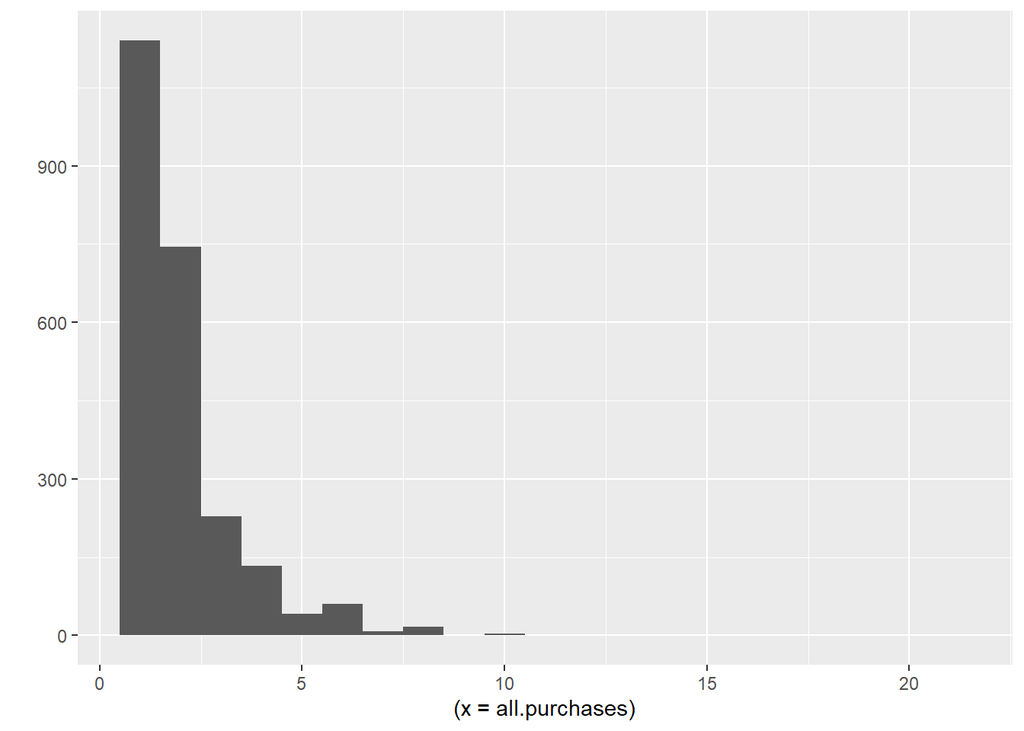

```r
qplot((x=all.purchases), data=yogurt, binwidth=1)
```

the histogram reveal that most household purchase one or two yogurt at a time. let investigate the price over time in more details. this is where a facebook data was defficeint. in this dataset we can examine changes and prices because we have data on the same households over time

###Instruction

Create a scatterplot of price vs time. This will be an example of a time series plot. Resolve overplotting issues by using techniques you learned in Lesson 4.

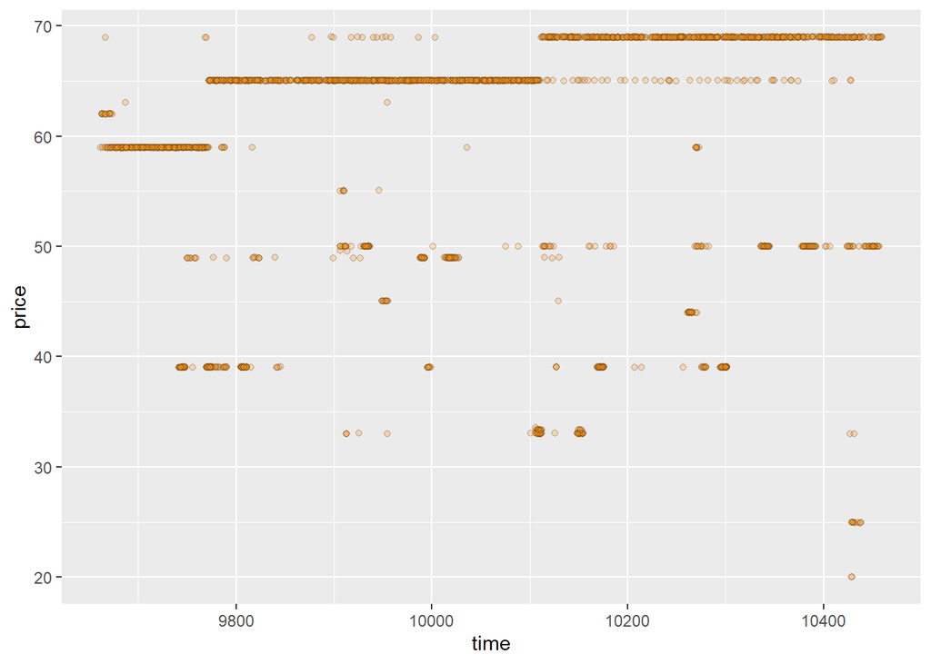

```r
ggplot(aes(x = time, y = price), data = yogurt) +
  geom_jitter(alpha = 1/4, shape=21, fill=I('#F79420'))
```

seeing the graph we can say that the model of most common prices, seem to be increasing over time. we also see some lower prices scatter about to the graph. these maybe due to sale or buyers using coupons that bring down the price of yogurt.  
***

### Sampling Observations

Notes:when familarizing ourselves with a dataset that contians mltiple observations of the same units, it often useful to work with a sample of those unit so that its easy to display the raw data for that sample. in our case of yogurt dataset we might want to look at a small set of household in more detail so that we know what kind of within and between household variation we are working with. this analysis of a sub-sample might come before trying to use within houshold variation as part of model. for example this data set was originally used to model consumer preferences for variety. but before doing that we would want to look at how often we observe household buying yogurt, how often they buy multiple items,and what prices they are buying yogurt at. one way to do this is to look at some sub-sample in more detail.lets pick 16 household ar random and take a closer look.  
***

### Looking at Samples of Households

```r
#using this will make  reproducable even if we use random sample
set.seed(4230)

#lets use 16 household sample. level is all the differnet household we have
sample.ids= sample(levels(yogurt$id), 16)

sample.ids
```

```
##  [1] "2154351" "2108704" "2118182" "2128116" "2125443" "2146035" "2101980"
##  [8] "2111922" "2167817" "2110965" "2122788" "2136960" "2103390" "2105346"
## [15] "2124305" "2144469"
```

Now, we can plot each purchase occassion for each of the household that we sampled. we have the time of the purchase, the price of item per yogurt and the number of items.

I am using size() to add more details to my plot and pass the all.purchase variable so that way i can consider the number of items purchased by a household in term of size of the point(smal circles in our case, we can change the circes by changeing the pch number or angle) on the plot.[graphical_paramters](https://www.statmethods.net/advgraphs/parameters.html)

id%in%sample.ids: just tells to loop over the ids that are in sample.ids variable.so that we go through and create a panel plot for each id of our household.

[laarn difference between a%in%b and a==b](https://stackoverflow.com/questions/42637099/difference-between-the-and-in-operators-in-r)

face_wrap make the panel for Ids…(we have already identified which ids in %in% methods)

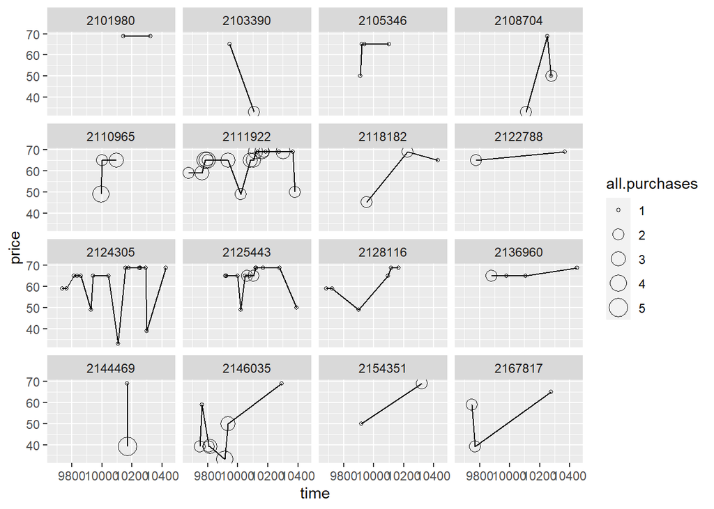

```r
ggplot(aes(x=time, y= price), data=subset(yogurt, id %in% sample.ids))+
    facet_wrap(~id)+geom_line()+
    geom_point(aes(size= all.purchases), pch=1)
```

#Another sample for of the household units: this time household sample.

```r
set.seed(5329)

sample.ids2= sample(levels(yogurt$id),10)
sample.ids2
```

```
##  [1] "2140483" "2167817" "2129767" "2122242" "2123471" "2105403" "2160549"
##  [8] "2166934" "2105346" "2143271"
```

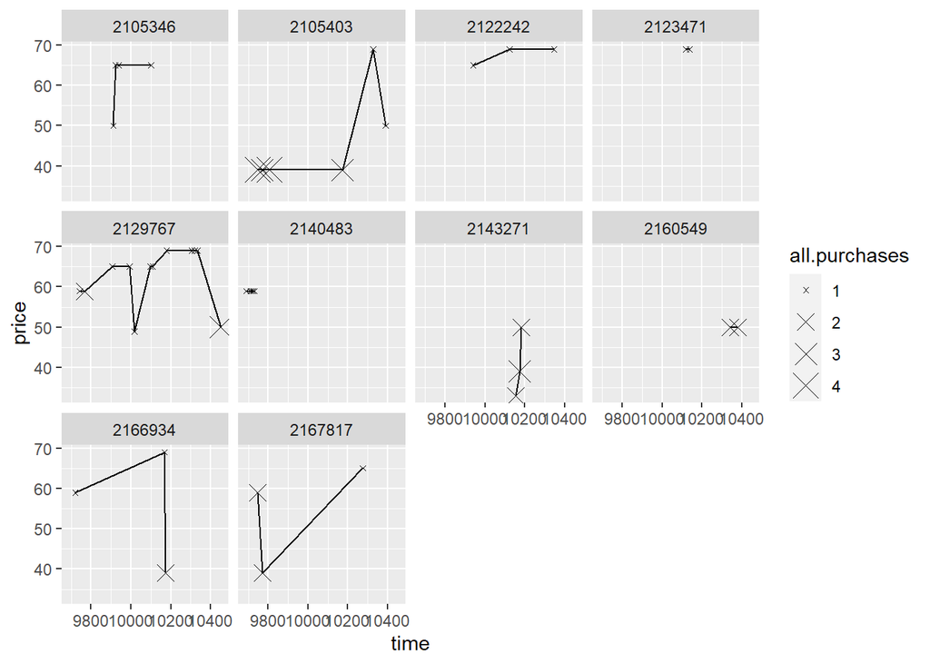

```r
ggplot(aes(x=time, y=price), data= subset(yogurt, id%in%sample.ids2))+
  facet_wrap(~id)+geom_line()+
  geom_point(aes(size=all.purchases), pch=4)
```

***

### The Limits of Cross Sectional Data

Notes: the general idea here is that if we have observatoin over time we can facet it by the primary unit, case, or individual in the data set. for our yogurt data it eas the households that we were faceting over. this faceted time series plot is something we cant generate with our pseudo facebook data set. since we dont havve data on our sample of users over time. lets get back to the facebook data plot:

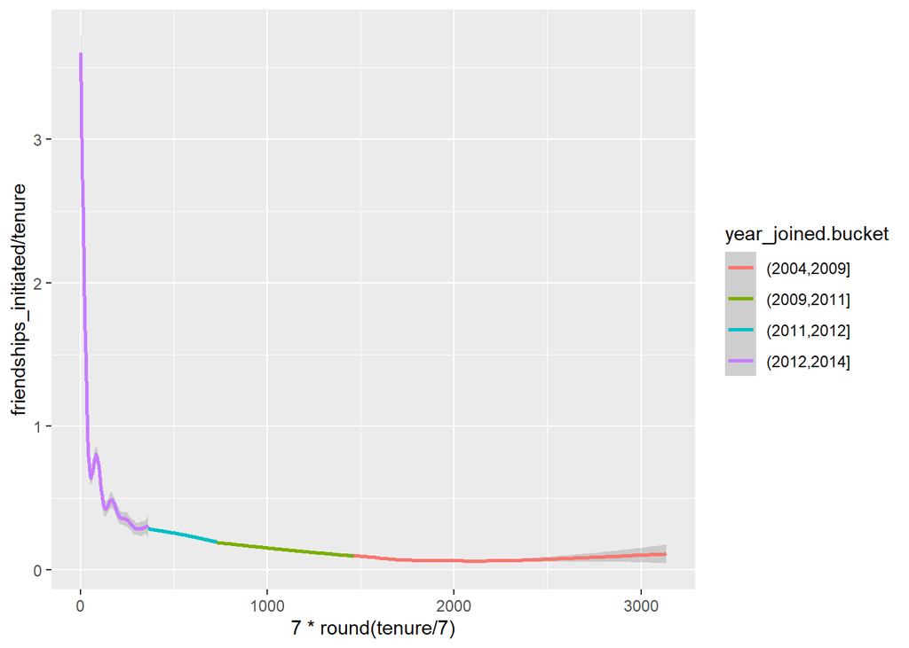

```r
ggplot(aes(x = 7 * round(tenure / 7), y = friendships_initiated / tenure),
       data = subset(fb, tenure > 0)) +
  geom_smooth(aes(color = year_joined.bucket))
```

the facebook data isnt great for examining the process of friends over time. this data set is just a cross section, its just one snap at a fixed point that tells us the characteristics of individual. not the individual over, say, a year. but if we had a dataset like yogurt one, we would be able to track the friendship_initiated over time and compare that with tenure. this would give us better evidence to explain the difference or the drop in friendship_initiated over time as tenure increases

### Many Variables

Notes:much of the analysis we have done so far is based on pre-chosen variables, relationship, or qestion of interest then use EDA to let those chose variables speak and surprise us. more recently when analyzing relationship between two variabele we incorporate more variables into the analysis to improve it. for example: by seeing weather a particular relationship is consistent across values of those other variables. in chosing a third, or four variable to plot we relied on our domain knowledge. but often we might want to visualization or summary to help us identify such auxilary variable. in some analysis we may plan to make use of large number of variables perhaps we planning on predicting one variable with 10, 20 or 100 of others. or maybe we wanna summarise a large set of variables into a samller set of dimensions or perhaps we are looking for interesting reslationship among a large set of variable. in such cases we can help speed up our exploratory analysis for data analysis for producing many plots or comparisons at once. this can be one way to let the dataset as a whole speak in part by drawing our attention to variables we didnt have pre existing interest ***

### Scatterplot Matrix

Notes:there is a tool that we can create a number of scatter plots automatically, its called a scatter plot matrix. in a scatter matrix there is grid of scatter plots between every pair of variables, as we have seen scatter plots are great bit not necessarily suited for all types of variables, for example, categorical ones. so there are other types of vizualizaton tha can be created instead of scatter plot like boxplot, or histograms where variables are categorical. lets produce our scatter plot matrix for our psuedo facebook data set.

```r
#install.packages('GGally')
library(GGally)
set.seed(2836)

#our dataset contains all different variables, and i actually dont want all these variables. i dont want userID, yearJoined, or year_joined.bucket. that's why i subset my DF and get sample from that subset. i didnt use year, and year_joined bucket, because those are categorical variables and really derived from tenure.



fb_subset=fb[,c(2:15)]
names(fb_subset)
```

```
##  [1] "age"                   "dob_day"               "dob_year"
##  [4] "dob_month"             "gender"                "tenure"
##  [7] "friend_count"          "friendships_initiated" "likes"
## [10] "likes_received"        "mobile_likes"          "mobile_likes_received"
## [13] "www_likes"             "www_likes_received"
```

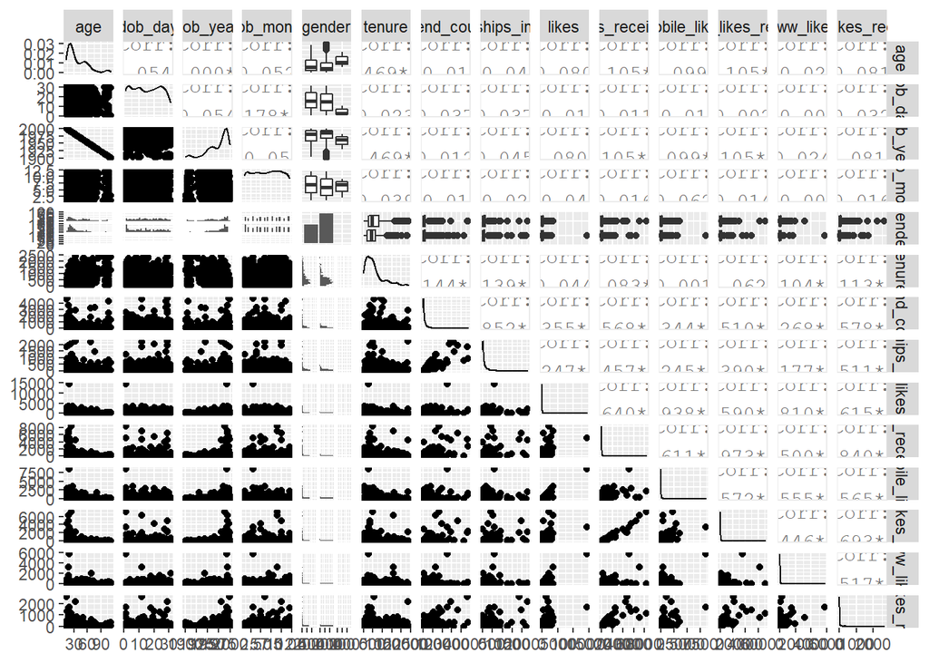

```r
ggpairs(fb_subset[sample.int(nrow(fb_subset),1000), ])
```

### Even More Variables

Notes:

### Heat Maps

Notes:

```r
nci <- read.table("nci.tsv")

#column names, we can also use: names(nci)
colnames(nci)
```

```
##  [1] "V1"  "V2"  "V3"  "V4"  "V5"  "V6"  "V7"  "V8"  "V9"  "V10" "V11" "V12"
## [13] "V13" "V14" "V15" "V16" "V17" "V18" "V19" "V20" "V21" "V22" "V23" "V24"
## [25] "V25" "V26" "V27" "V28" "V29" "V30" "V31" "V32" "V33" "V34" "V35" "V36"
## [37] "V37" "V38" "V39" "V40" "V41" "V42" "V43" "V44" "V45" "V46" "V47" "V48"
## [49] "V49" "V50" "V51" "V52" "V53" "V54" "V55" "V56" "V57" "V58" "V59" "V60"
## [61] "V61" "V62" "V63" "V64"
```

```r
#changing the column names to produce much nicer plot
colnames(nci) <- c(1:64)

colnames(nci)
```

```
##  [1] "1"  "2"  "3"  "4"  "5"  "6"  "7"  "8"  "9"  "10" "11" "12" "13" "14" "15"
## [16] "16" "17" "18" "19" "20" "21" "22" "23" "24" "25" "26" "27" "28" "29" "30"
## [31] "31" "32" "33" "34" "35" "36" "37" "38" "39" "40" "41" "42" "43" "44" "45"
## [46] "46" "47" "48" "49" "50" "51" "52" "53" "54" "55" "56" "57" "58" "59" "60"
## [61] "61" "62" "63" "64"
```

Note:  
we want to display for each combination of gene and sample case, the differnece in gene expression and the sample from the base line. we want to display combinations where a gene is over expressed in red and combination where gene is under-expressed in blue

```r
library(reshape2)


#change wide data to long
nci.long.samp <- melt(as.matrix(nci[1:200,]))

#set column names for the sample
names(nci.long.samp) <- c("gene", "case", "value")
head(nci.long.samp)
```

```
##   gene case  value
## 1    1    1  0.300
## 2    2    1  1.180
## 3    3    1  0.550
## 4    4    1  1.140
## 5    5    1 -0.265
## 6    6    1 -0.070
```

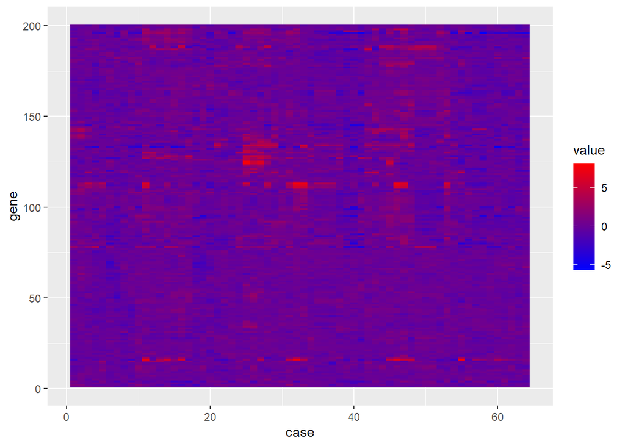

```r
#plot heatmap
#
ggplot(aes(y = gene, x = case, fill = value),
  data = nci.long.samp) +
  geom_tile() +
  scale_fill_gradientn(colours = colorRampPalette(c("blue", "red"))(100))
```

### Analyzing Three of More Variables

Reflection:

Click **KnitHTML** to see all of your hard work and to have an html page of this lesson, your answers, and your notes!